# Section 2: Health Insurance

Ian McCarthy | Emory University

Econ 372

# Table of contents

1. Motivation
2. Insurance and Risk
3. Demand for Health Insurance
4. Adverse Selection
5. U.S. Health Insurance Policy

class: inverse, center, middle name: motivate

# Managing risk is really important

.pull-left[

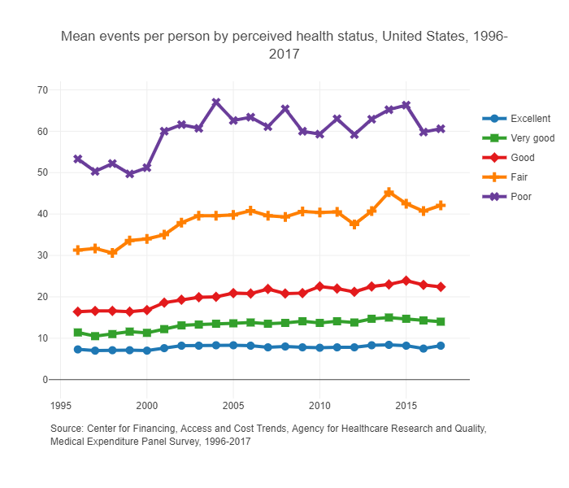

]

.pull-right[

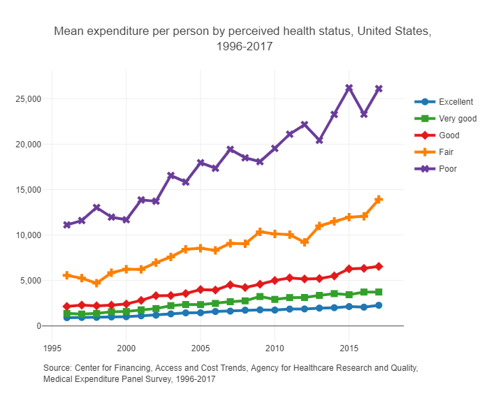

]

Source: [Medical Expenditure Panel Survey](https://meps.ahrq.gov/mepstrends/hc_use/)

class: inverse, center, middle name: risk

# 1. Probability

Definition: The likelihood that a given outcome will occur.

–

Important to note the timing here…probability applies to an uncertain event that may have several possible outcomes. For example, I may have a heart attack or I may not. [Risk Calculator](http://www.cvriskcalculator.com/).

# Example

What is my expected cost? - Two possible outcomes: heart attack or no heart attack - 10% chance of having a heart attack - Cost of $100,000 if I have a heart attack (but I will survive and recover)

# 3. Preferences

Definition: Preferences take the form of a utility function, $u(x)$, which tells us how much we benefit get from some consumption bundle, $x$.

–

Expected utility the combines expected value and utility…  
$E[u(x)] = p_{1}u(x_{1}) + p_{2}u(x_{2})$

# Risk aversion

Most common assumption is that individuals are risk averse. Mathematically, this follows from diminishing marginal utility.

–

$u'(x_{1}) > u'(x_{2})$ for $x_{1} < x_{2}$  
What does this mean in words?

# In-class Problem: Expected values

An individual starts with a wealth of $100,000. With probability 0.3, they will get sick and incur a cost of $40,000.

1. What is this person’s expected cost of illness?
2. Assume this individual has a utility function of the form, $u(w) = w^{0.20}$. What is this person’s expected utility?
3. Calculate this person’s utility if they were to incur the cost of illness with certainty. Is this utility higher or lower than what you found in part (2)?

class: inverse, center, middle name: demand

# Demand for Health Insurance

# Answer

# Risk Premium

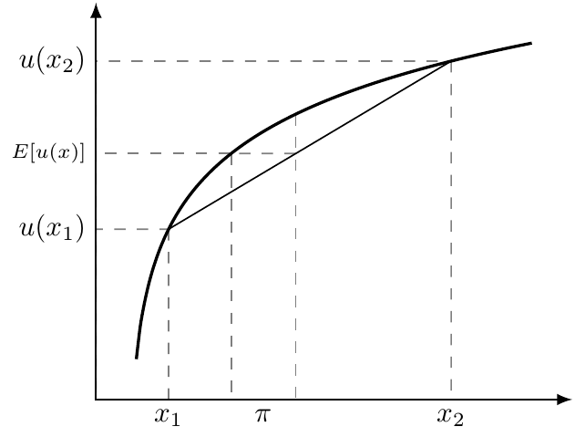

# Answer

The person’s expected utility with uncertainty is: $E[u]=0.75\times \ln (100000) + 0.25 \times \ln (80000) =$ 11.4571396. We therefore need to find $y$ such that $u(y)=$ 11.4571396. Given our utility function, this is satisfied for $y=$ $94,574. Since the person starts with $100,000, they are willing to pay a maximum of $100,000 $-$ $94,574 $=$ $5,425.8 for health insurance.

Finally, since the expected cost of care is $5,000, we can break this $5,425.8 into its actuarily fair premium of $5,000 plus the loading factor or risk premium of $425.84.

# What affects the risk premium?

Based on the graph, what do you think are some things that might affect the risk premium?

–

1. Curvature of the utility function
2. Probability of illness
3. Cost of illness

# Other reasons to buy health insurance

1. Increase bargaining power with providers
2. Manage where care is delivered (due to information problems in health care decisions)

class: inverse, center, middle name: selection

# Textbook adverse selection

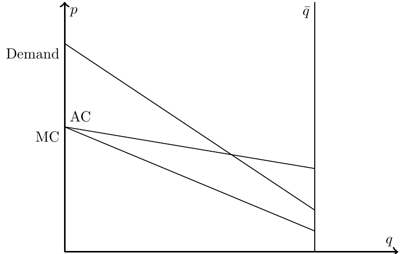

# Unravelling

For any amount of unravelling, we need at least two features in the market:

1. Individuals select plans based on health needs (which is private information)
2. Common price to all enrollees of a given plan (community rating)

# Answer

# Death spiral!

[Paul Ryan on Death Spirals](https://www.washingtonpost.com/videonational/ryan-obamacare-is-in-death-spiral/2017/01/05/375a49da-d366-11e6-9651-54a0154cf5b3_video.html)

# Death spiral!

So, are the exchanges in a “death spiral”?

[output not shown]

# Some potential policy solutions

1. Subsidize consumers
2. Subsidize insurers
3. Mandate purchases

–

Can you examine each of these policies graphically? How do they differ from the patient’s or government’s point of view?

# Advantageous selection

What if individuals who are high risk are also less risk-averse? In this case, individuals who are willing to pay the most for health insurance (the most risk averse) are actually less risky and therefore the cheapest to insure. Very different policy implications (e.g., individual mandate is bad in this case).

class: inverse, center, middle name: policy

# U.S. Health Insurance Policy

# Current policy

1. Increasingly reliant on private market, even for public insurance programs, where adverse selection is most salient
2. [Health insurance exchanges](https://www.cms.gov/CCIIO/Programs-and-Initiatives/Health-Insurance-Marketplaces/index.html)
3. [Individual mandate](https://www.healthcare.gov/fees/fee-for-not-being-covered/)
4. [Premium and cost-sharing subsidies](http://www.kff.org/health-reform/issue-brief/explaining-health-care-reform-questions-about-health/)
5. [Insurer subsidies](http://www.kff.org/health-reform/issue-brief/explaining-health-care-reform-risk-adjustment-reinsurance-and-risk-corridors/)
6. Medicaid expansion
7. [Risk adjustment](https://www.cms.gov/Medicare/Health-Plans/MedicareAdvtgSpecRateStats/Downloads/RTC-Dec2018.pdf)

# Your questions

1. Why so much opposition to the ACA?
2. Why repeal the existing provisions in the ACA that cover pre-existing conditions?
3. What does open enrollment entail and what qualifies someone for open enrollment?
4. What are the differences between employer-provided healthcare and healthcare provided by the ACA?
5. I’m wondering if the ACA affects Medicaid in any way
6. Other than insurance, in what ways does the ACA affect the healthcare market?

# In context

We motivated this entire section of the class with the example of Humana withdrawing from the ACA exchanges. This example and our policy discussion highlight at least four things: 1. Patient health has a major effect on insurer costs (we showed this with some basic problems). 2. There is theoretically less available profit with a really sick patient pool (we showed this too). Budget contstraints compound this problem. 3. With community ratings, standard insurance market will leave some people uninsured who are willing and able to purchase. 4. Lots of policy levers to address these issues.